# Machine Learning - Fitness Data

Edgar Ruiz

August 22, 2015

## Summary

- Random Forest is the method selected for the analysis
- Separated the data into 40% training/testing and 60% validation
- Cross-validation will occur within each run of the random forest tree
- Performed some variable pre-selection to increase training speed

## Loading and partitioning data

```r
# Loading libraries, seeds and file in the outset -----------------------------------------------------------
library(caret)
set.seed(1710)
activity <- read.csv("pml-training.csv")
```

Larger training sets were causing computer processor problems. At 40%, the accuracy rate became acceptable.

```r
training.rows <- createDataPartition(y=activity$classe, p=0.4, list=FALSE)
training<- activity[training.rows,]
validate <- activity[-training.rows,]
```

## Data Processing

### Variable pre-selection

3 stages for pre-selection, removed variables with near zero variance, those with no correlation to any other variable, and those with not needed to train the model.

```r
# Sepparating 'classe' to prepare the rest of the variables for variable pre-selection ----------------------
classe <- training$classe
# Using Near Zero Variance to identify and remove -----------------------------------------------------------
training.var <- nearZeroVar(training, saveMetrics=TRUE)
training.nzv <-  subset(training.var, nzv==FALSE)
training <- subset(training, select=c(rownames(training.nzv)))
# Removed specific variables, identified during data discovery ----------------------------------------------
training <- subset(training, select=-c( X,raw_timestamp_part_1, raw_timestamp_part_2,cvtd_timestamp, classe,user_name,num_window ))
# Using correlation to identify and remove those variables with NA correlation ------------------------------
training.cor <- cor(training)[1,]
training.NA <- is.na(training.cor)
training.cor <- training.cor[training.NA==FALSE]
training <- subset(training, select=c(rownames(as.data.frame(training.cor))))
training <- cbind(classe, training)
```

## Model fitting and analysis

Used most defaults for the Random Forest method to fit the model. Due to long processing times, the number of trees were specified to 10.

```r
training.fit <- train(classe~., data=training, method="rf", prox=TRUE, ntree=10)
```

### Random Forest results - Cross validation and Predictor Selection

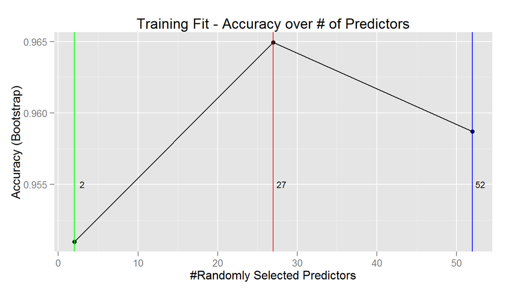

```r
ggplot(training.fit)+geom_vline(xintercept=training.fit$results$mtry, colour=c("green","red","blue"))+labs(title="Training Fit - Accuracy over # of Predictors")+geom_text(label=training.fit$results$mtry, x=training.fit$results$mtry+1, y=0.955, size=3)
```

```r
training.fit
```

```
## Random Forest
##
## 7850 samples
##   52 predictor
##    5 classes: 'A', 'B', 'C', 'D', 'E'
##
## No pre-processing
## Resampling: Bootstrapped (25 reps)
## Summary of sample sizes: 7850, 7850, 7850, 7850, 7850, 7850, ...
## Resampling results across tuning parameters:
##
##   mtry  Accuracy   Kappa      Accuracy SD  Kappa SD
##    2    0.9509966  0.9379830  0.004550315  0.005732308
##   27    0.9649471  0.9556489  0.004450058  0.005614319
##   52    0.9587053  0.9477550  0.005575277  0.007056712
##
## Accuracy was used to select the optimal model using  the largest value.
## The final value used for the model was mtry = 27.
```

- The **cross-validation** was performed using 25 repetitions of Bootstrapping, and each sample size was 7,850
- Best number of predictors was 27, plot and summary show a decrease in Accuracy when using more predictors

### Selected model - Expected error rate

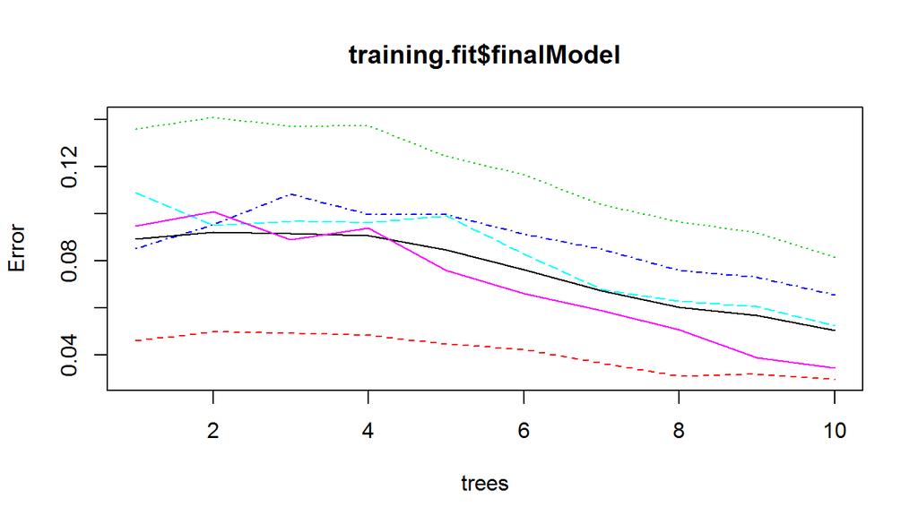

```r
plot(training.fit$finalModel)
```

```r
print(training.fit$finalModel)
```

```
##
## Call:
##  randomForest(x = x, y = y, ntree = 10, mtry = param$mtry, proximity = TRUE)
##                Type of random forest: classification
##                      Number of trees: 10
## No. of variables tried at each split: 27
##
##         OOB estimate of  error rate: 5.05%
## Confusion matrix:
##      A    B    C    D    E class.error
## A 2140   30   12   17    6  0.02947846
## B   52 1375   46   11   13  0.08149633
## C    7   50 1267   17   15  0.06563422
## D   11   13   32 1210   11  0.05246672
## E    5   13   11   20 1373  0.03445851
```

## Validating model

```r
validate.pred <- predict(training.fit, validate)
validate.matrix <- confusionMatrix(validate.pred, validate$classe)
validate.accuracy  <-validate.matrix$overall[1]
validate.error <- 1-validate.accuracy

print(paste("Validation sample size: ", length(validate.pred)));print(paste("Accuracy:" , round(validate.accuracy,digits=4)));print(paste("Validation error rate: " , round(validate.error,digits=4)))
```

```
## [1] "Validation sample size:  11772"
```

```
## [1] "Accuracy: 0.9758"
```

```
## [1] "Validation error rate:  0.0242"
```

- Validation returned an even lower error rate than the average out of sample error rate obtained during training
- Likelihood of over fitting is low due to the low error rate obtained

## Testing model

Running the model against the observations in the submission data set and creating the files.

```r
submission <- read.csv("pml-testing.csv")
submission.rf <- predict(training.fit, submission)
for(i in 1:length(submission.rf)){write.table(submission.rf[i], file=paste("problem_id_",i,".txt"),quote=FALSE,row.names=FALSE,col.names=FALSE)}
```

The model accurately solved for all 20 of the problems, once the resulting files were uploaded.